# Prediction Assignment Writeup

kojikami

February 21, 2015

## Objective of this Project

> The goal of your project is to predict the manner in which they did the exercise. This is the “classe” variable in the training set. You may use any of the other variables to predict with. You should create a report describing how you built your model, how you used cross validation, what you think the expected out of sample error is, and why you made the choices you did. You will also use your prediction model to predict 20 different test cases.

## Data Collection & Cleansing

```r
train_url <-
        "https://d396qusza40orc.cloudfront.net/predmachlearn/pml-training.csv"
test_url <-
        "https://d396qusza40orc.cloudfront.net/predmachlearn/pml-testing.csv"
download.file(train_url, destfile = "data/training.csv", method = "curl")
download.file(test_url, destfile = "data/testing.csv", method = "curl")
train <- read.csv("data/training.csv", na.strings=c("NA","#DIV/0!",""))
test <- read.csv("data/testing.csv", na.strings=c("NA","#DIV/0!",""))
```

### Setting up Packages

```r
library(caret)
library(kernlab)
library(AppliedPredictiveModeling)
library(randomForest)
```

```r
library(ggplot2)
library(Metrics)
```

## Features Selection for Analysis

For the reason that from train data from 1 to 7 column is not necessary for prediction, then we subset train data: remove user name, window, and time. Remove the columns that contain `NAs`, because columns which contain `NAs` will not predict good. Use training set and split into `training_train` and `training _test` sets and build model on training set.The function `createDataPartition` can be used to create balanced splits of the data. If the y argument to this function is a factor, the random sampling occurs within each class and should preserve the overall class distribution of the data. For this project, create a single 75% and 25% split of the data.

```r
training <- train[,-c(1:7)]
set.seed(100)
inTrain <- createDataPartition(training$classe, p = 0.75, list = FALSE)
training_train <- training[inTrain,]
training_test <- training[-inTrain,]
dim(training_train)
```

```
## [1] 14718   153
```

```r
training_train <- as.data.frame(training_train)
clean_train <- training_train[, colSums(is.na(training_train)) == 0]
clean_test <- training_test[, colSums(is.na(training_test)) == 0]
```

## Modeling & Analysis

```r
set.seed(150)
tr <- trainControl(method = "cv", number = 5)
#first prediction model
modelFit1 <- train(classe ~., data = clean_train,
                   method = "rf", trControl = tr)
prediction1 <- predict(modelFit1, clean_train)
print(modelFit1)
```

```
## Random Forest
##
## 14718 samples
##    52 predictor
##     5 classes: 'A', 'B', 'C', 'D', 'E'
##
## No pre-processing
## Resampling: Cross-Validated (5 fold)
##
## Summary of sample sizes: 11774, 11775, 11775, 11774, 11774
##
## Resampling results across tuning parameters:
##
##   mtry  Accuracy  Kappa   Accuracy SD  Kappa SD
##    2    0.9919    0.9898  0.002271     0.002873
##   27    0.9911    0.9887  0.002602     0.003293
##   52    0.9847    0.9807  0.003107     0.003931
##
## Accuracy was used to select the optimal model using  the largest value.
## The final value used for the model was mtry = 2.
```

```r
summary(modelFit1$finalModel)
```

```
##                 Length Class      Mode
## call                4  -none-     call
## type                1  -none-     character
## predicted       14718  factor     numeric
## err.rate         3000  -none-     numeric
## confusion          30  -none-     numeric
## votes           73590  matrix     numeric
## oob.times       14718  -none-     numeric
## classes             5  -none-     character
## importance         52  -none-     numeric
## importanceSD        0  -none-     NULL
## localImportance     0  -none-     NULL
## proximity           0  -none-     NULL
## ntree               1  -none-     numeric
## mtry                1  -none-     numeric
## forest             14  -none-     list
## y               14718  factor     numeric
## test                0  -none-     NULL
## inbag               0  -none-     NULL
## xNames             52  -none-     character
## problemType         1  -none-     character
## tuneValue           1  data.frame list
## obsLevels           5  -none-     character
```

```r
confusionMatrix(predict(modelFit1, newdata = clean_test), clean_test$classe)
```

```
## Confusion Matrix and Statistics
##
##           Reference
## Prediction    A    B    C    D    E
##          A 1394    3    0    0    0
##          B    1  941    5    0    0
##          C    0    5  849   13    0
##          D    0    0    1  790    3
##          E    0    0    0    1  898
##
## Overall Statistics
##
##                Accuracy : 0.993
##                  95% CI : (0.991, 0.996)
##     No Information Rate : 0.284
##     P-Value [Acc > NIR] : <2e-16
##
##                   Kappa : 0.992
##  Mcnemar's Test P-Value : NA
##
## Statistics by Class:
##
##                      Class: A Class: B Class: C Class: D Class: E
## Sensitivity             0.999    0.992    0.993    0.983    0.997
## Specificity             0.999    0.998    0.996    0.999    1.000
## Pos Pred Value          0.998    0.994    0.979    0.995    0.999
## Neg Pred Value          1.000    0.998    0.999    0.997    0.999
## Prevalence              0.284    0.194    0.174    0.164    0.184
## Detection Rate          0.284    0.192    0.173    0.161    0.183
## Detection Prevalence    0.285    0.193    0.177    0.162    0.183
## Balanced Accuracy       0.999    0.995    0.994    0.991    0.998
```

```r
table(prediction1, clean_train$classe)
```

```
##
## prediction1    A    B    C    D    E
##           A 4185    0    0    0    0
##           B    0 2848    0    0    0
##           C    0    0 2567    0    0
##           D    0    0    0 2412    0
##           E    0    0    0    0 2706
```

## Prediction

```r
#predict train_test data
modelFit2 <- train(classe~., data = clean_test,
                   method = "rf", trControl = tr)
prediction2 <- predict(modelFit1, newdata = clean_test)
table(prediction2, clean_test$classe)
```

```
##
## prediction2    A    B    C    D    E
##           A 1394    3    0    0    0
##           B    1  941    5    0    0
##           C    0    5  849   13    0
##           D    0    0    1  790    3
##           E    0    0    0    1  898
```

```r
sum(clean_test$classe == predict(modelFit1, clean_test)) / nrow(clean_test)
```

```
## [1] 0.9935
```

```r
test <- test[,colSums(is.na(test)) == 0]
test <- test[,-c(1:7)]
#predict test data
prediction3 <- predict(modelFit2, newdata = test)
```

## Submission

```r
#coursera code
pml_write_files = function(x){
        n = length(x)
        for(i in 1:n){
                filename = paste0("problem_id_",i,".txt")
                write.table(x[i], file = filename, quote = FALSE,
                            row.names = FALSE, col.names = FALSE)
        }
}

pml_write_files(prediction3)
```

## Appendix

Figure1: Plot of modelFit

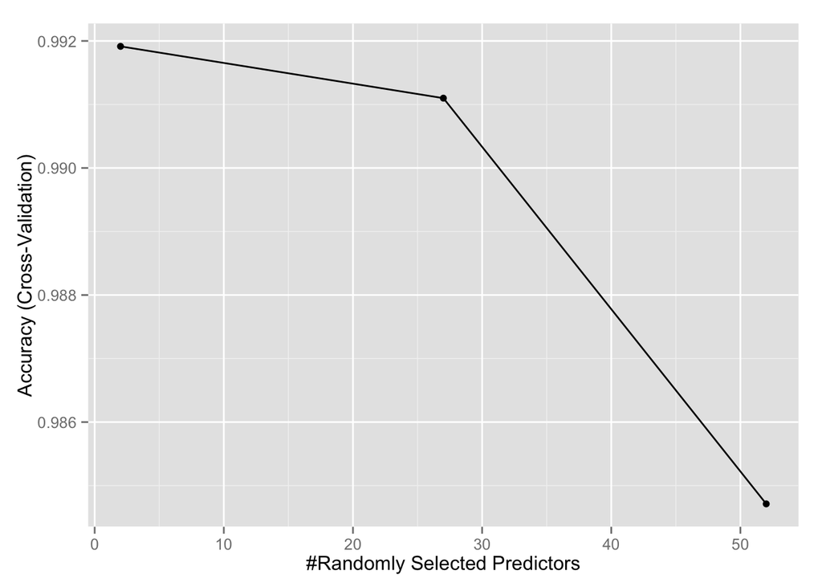

```r
ggplot(modelFit1)
```

Figure2: Importance of variables

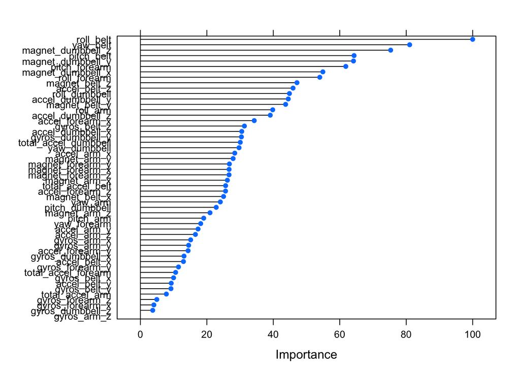

```r
plot(varImp(modelFit1))
```

Figure3: Prediction plot

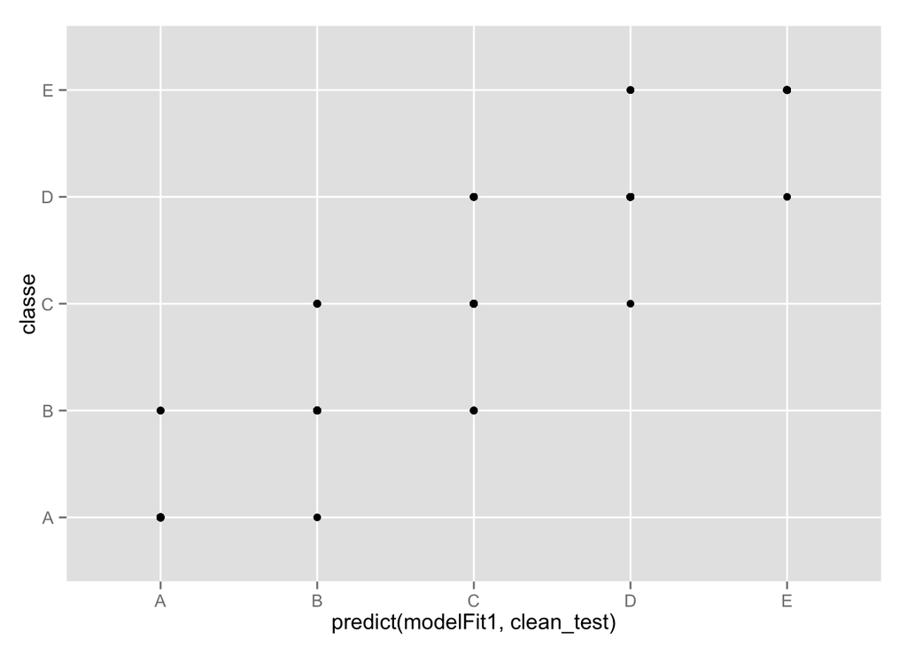

```r
qplot(predict(modelFit1,clean_test), classe, data=clean_test)
```